# Lab 1

https://github.com/carsonn-k/Machine-Learning-Class-Git/tree/main/Lab%201

## Task 1

1.1 The aesthetics being used here are income on the x-axis, life expectancy on the y-axis, the colors are based on continent, and the size of each bubble is based on population.

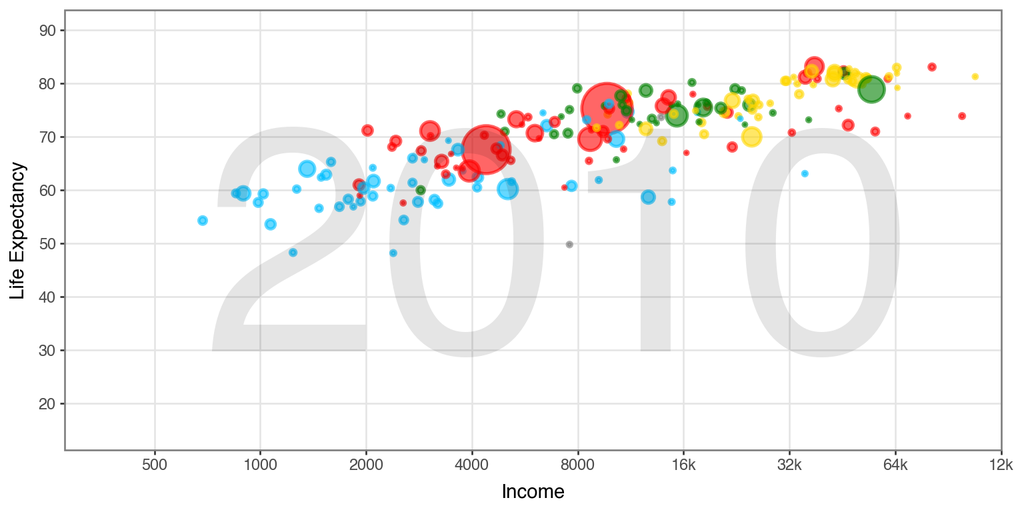

```python
import pandas as pd

df = pd.read_csv("/Users/kellogg/Downloads/Cal Poly 5th Year/Machine-Learning-Class-Git/Lab 1/Data/q1data.csv")

from plotnine import *

(ggplot(df,
aes(
  x = "income",
  y = "life_exp",
  color = "four_regions",
  size = "population",
))
+ geom_point(alpha = 0.6, stroke = 1)
+ scale_x_log10(limits = (0, 128000),
    breaks = [500, 1000, 2000, 4000, 8000, 16000, 32000, 64000, 128000],
    labels = ["500", "1000", "2000", "4000", "8000", "16k", "32k", "64k", "12k"])
+ scale_y_continuous(limits = (15, 90), breaks = list(range(20,91,10)))
+ scale_color_manual(values = {'americas': 'green', 'asia': 'red', 'africa': 'deepskyblue', 'europe': 'gold'})
+ scale_size(range = (0, 15))
+ theme_bw()
+ theme(panel_grid_minor=element_blank(), figure_size=(8, 4))
+ theme(legend_position = 'none')
+ labs(x = "Income", y='Life Expectancy')
+ annotate("text", x = 7000, y = 45, label = "2010", size = 180, alpha = 0.1, ha = "center", va = "center")

)
```

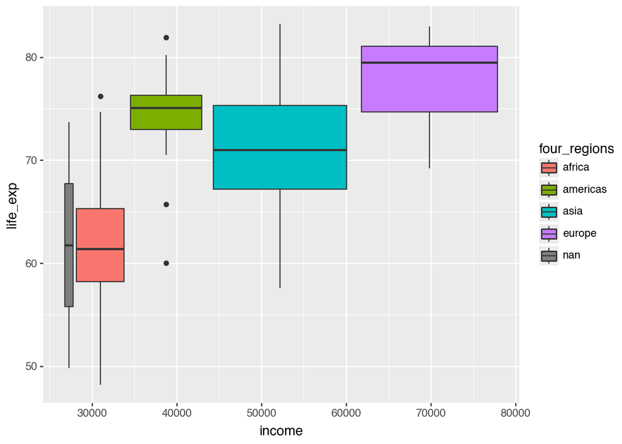

```python
(ggplot(df,
aes(
  x = "income",
  y = "life_exp",
  fill = "four_regions"))
+ geom_boxplot()
)
```

This box and whisker plot shows us some interesting things that aren’t as directly apparent in the bubble chart. Firstly, it’s easier to see which continent has lower incomes. It is also easier to see the dispersion of life expectancies within each continent. On the contrary, the bubble chart shows us some more information. It is easier to see the trend of income vs life expectancy. Additionally, the bubble chart incorporates the population.

## Task 2

2.1 The aesthetics being used here are exports on the x-axis, imports on the y-axis, the colors are based on continent, and the size of each bubble is based on energy usage.

import pandas as pd

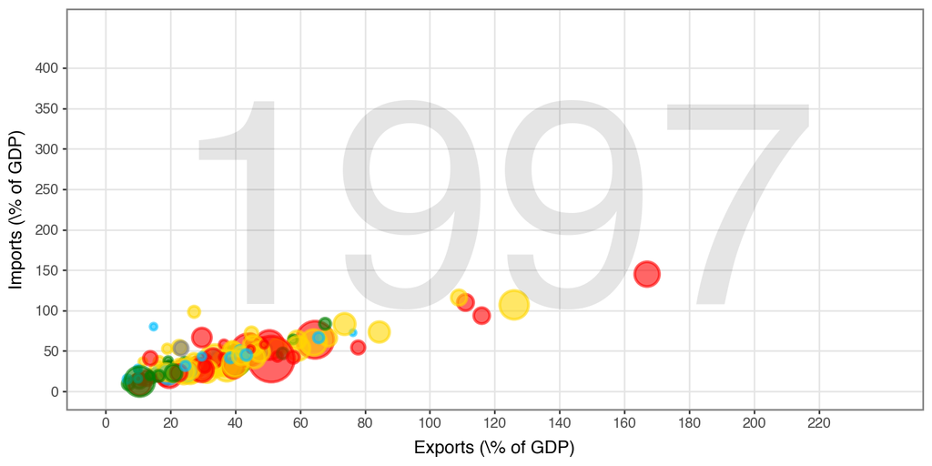

```python
import pandas as pd
df2 = pd.read_csv("/Users/kellogg/Downloads/Cal Poly 5th Year/Machine-Learning-Class-Git/Lab 1/Data/q2data.csv")

def convert_energy(val):
    val = str(val)
    if val.endswith("k"):
        return float(val[:-1]) * 1000
    return float(val)

df2["energy"] = df2["energy"].apply(convert_energy).astype(float)


from plotnine import *

(ggplot(df2,
aes(
  x = "exports",
  y = "imports",
  color = "four_regions",
  size = "energy",
))
+ geom_point(alpha = 0.6, stroke = 1)
+ scale_x_continuous(limits = (0, 240), breaks = list(range(0,240,20)))
+ scale_y_continuous(limits = (0, 450), breaks = list(range(0,401,50)))
+ scale_color_manual(values = {'americas': 'green', 'asia': 'red', 'africa': 'deepskyblue', 'europe': 'gold'})
+ scale_size(range = (0, 15))
+ theme_bw()
+ theme(panel_grid_minor=element_blank(), figure_size=(8, 4))
+ theme(legend_position = 'none')
+ labs(x='Exports (\% of GDP)', y='Imports (\% of GDP)')
+ annotate("text", x = 120, y = 200, label = "1997", size = 180, alpha = 0.1, ha = "center", va = "center")


)
```

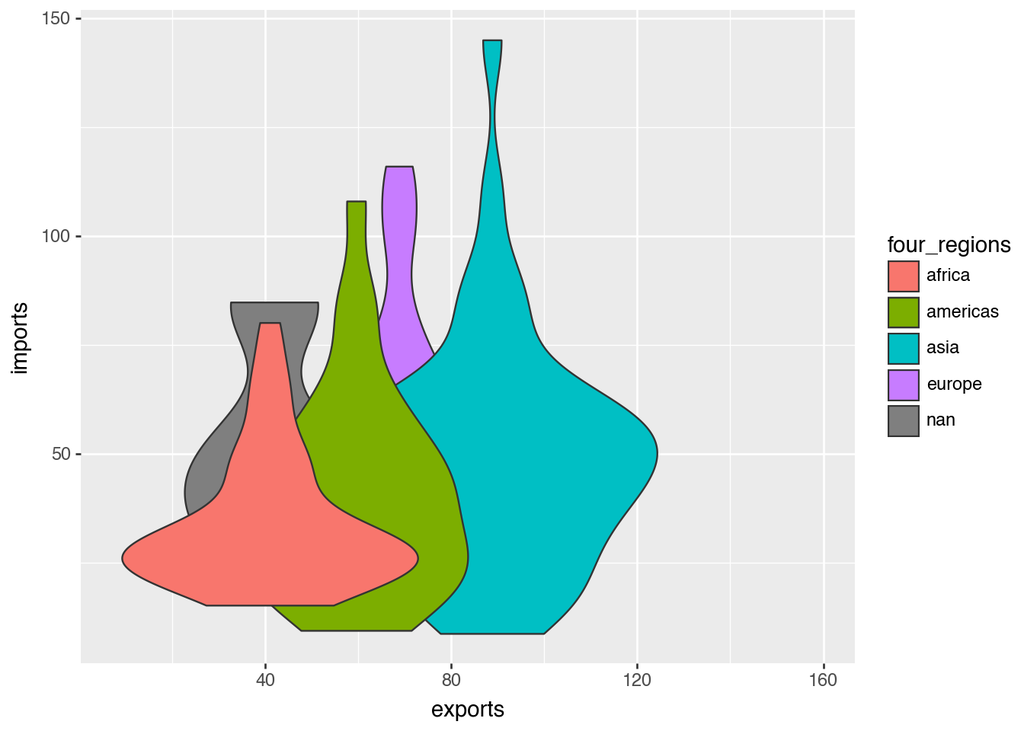

```python
(ggplot(df2,
aes(
  x = "exports",
  y = "imports",
  fill = "four_regions"))
+ geom_violin()
)
```

This violin chart is similar to the box and whisker chart where I think it makes it really easy to see which regions have higher values on the x-axis which in this case is exports. Other than that, I find the bubble chart to show the data better.

## Task 3

3.1 The aesthetics being used here are internet users on the x-axis, gdp per capita on the y-axis, the colors are based on continent, and the size of each bubble is based on income.

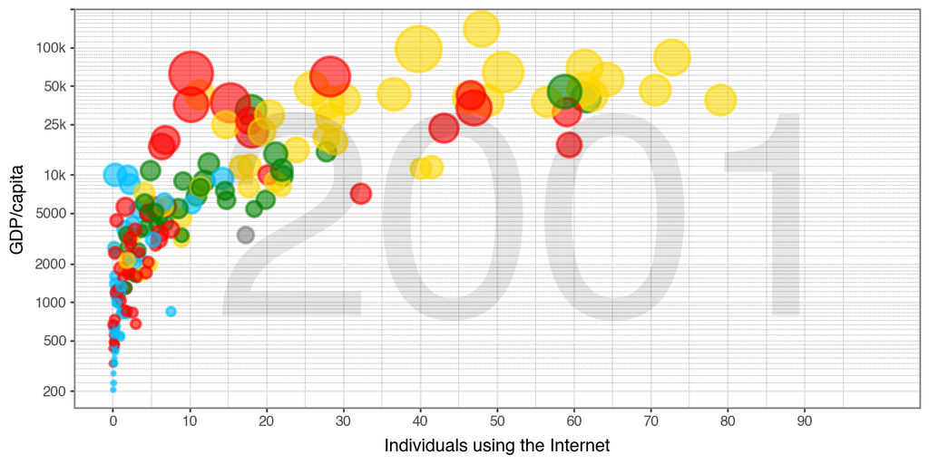

```python
df3 = pd.read_csv("/Users/kellogg/Downloads/Cal Poly 5th Year/Machine-Learning-Class-Git/Lab 1/Data/q3data.csv")

from plotnine import *

(ggplot(df3,
aes(
  x = "internet_users",
  y = "gdp",
  color = "four_regions",
  size = "income",
))
+ geom_point(alpha = 0.6, stroke = 1)
+ scale_x_continuous(limits = (0, 100), breaks = list(range(0,100,10)))
+ scale_y_log10(limits = (0, 200000),
    breaks = [200, 500, 1000, 2000, 5000, 10000, 25000, 50000, 100000, 200000],
    labels = ["200", "500", "1000", "2000", "5000", "10k", "25k", "50k", "100k", ""])
+ scale_color_manual(values = {'americas': 'green', 'asia': 'red', 'africa': 'deepskyblue', 'europe': 'gold'})
+ scale_size(range = (0, 15))
+ theme_bw()
# + theme(figure_size = (9,4))
+ theme(panel_grid_minor=element_line(color='black', size=0.2, linetype='dotted'), figure_size=(8, 4))
+ labs(x = 'Individuals using the Internet', y = 'GDP/capita')
+ theme(legend_position = 'none')
+ annotate("text", x = 55, y = 3000, label = "2001", size = 180, alpha = 0.1, ha = "center", va = "center")

)
```

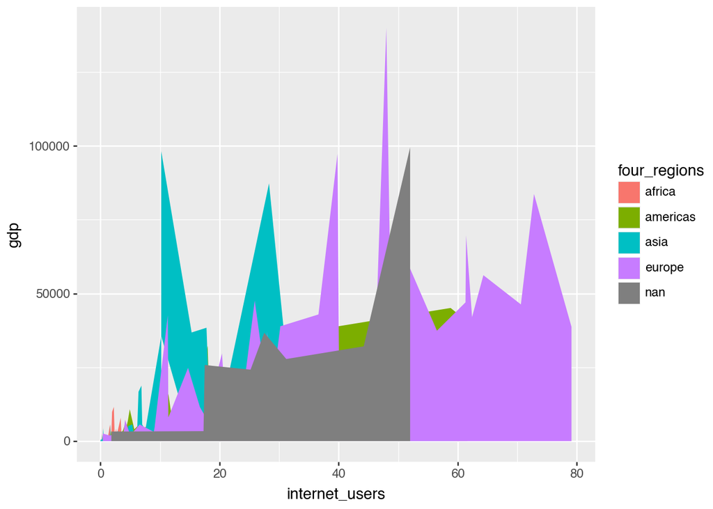

```python
(ggplot(df3,
aes(
  x = "internet_users",
  y = "gdp",
  fill = "four_regions"
))
+ geom_area()
)
```

This stacked area chart is showing internet users vs gdp based on the four regions. This chart is hard to read and does not really show us much besides which region has the most internet users. Again, I found the bubble chart to be much better.